# EDA - Take Home (Day 4) - Solutions [V2.0 - 270320]

|  | Take-Home (Day 4) |
| --- | --- |

### About the dataset (Life Expectancy Data)

The dataset contains the health data of 2938 individuals useful for predicting the life expentency of the individuals. The features are related to economical factors, immunity realted factors, social factors and so on.

Attribute Information:

**Country:** Country of the recorded data

**Year:** Year of the recorded data

**Status:** Status of the country

**Life expectancy:** Life expectancy in age (target/dependent variable)

**Adult mortality:** Rate of adult mortality

**Infant deaths:** Number of Infant Deaths per 1000 population

**Alcohol:** Alcohol consumption (in litres of pure alcohol)

**Percentage expenditure:** Expenditure on health as a percentage of GDP

**Hepatitis B:** Hepatitis B immunization coverage among 1-year-olds (%)

**Measles:** Number of reported cases per 1000 population

**BMI:** Average BMI of entire population

**Under-five deaths:** Number of under-five deaths per 1000 population

**Polio:** Polio immunization coverage among 1-year-olds (%)

**Total expenditure:** Government expenditure on health as a percentage of total government expenditure (%)

**Diphtheria:** DTP3 immunization coverage among 1-year-olds (%)

**HIV/AIDS:** Deaths per 1000 live births HIV/AIDS (0-4 years)

**GDP:** Gross Domestic Product per capita (in USD)

**Population:** Population of the country

**Thinness 1-19 years:** Prevalence of thinness for age 1 to 19 (%)

**Thinness 5-9 years:** Prevalence of thinness for age 5 to 9 (%)

**Income composition of resources:** Human Development Index in terms of income composition of resources

**Schooling:** Number of years of Schooling

**Import the required libraries**

```python
# import pandas
import pandas as pd

# import numpy
import numpy as np

# import matplotlib.pyplot
import matplotlib.pyplot as plt

# import seaborn
import seaborn as sns

# to suppress the warnings
import warnings
warnings.filterwarnings('ignore')

# to display all rows and columns
pd.options.display.max_columns = None
pd.options.display.max_rows = None
```

#### Load the life expectancy dataset and print the first five observations

```python
# load the csv file
df_life = pd.read_csv('Life Expectancy Data.csv')

# display the first five observations
df_life.head()
```

|  | Country | Year | Status | Life expectancy | Adult mortality | Infant deaths | Alcohol | Percentage expenditure | Hepatitis B | Measles | BMI | Under-five deaths | Polio | Total expenditure | Diphtheria | HIV/AIDS | GDP | Population | Thinness 1-19 years | Thinness 5-9 years | Income composition of resources | Schooling |
| --- | --- | --- | --- | --- | --- | --- | --- | --- | --- | --- | --- | --- | --- | --- | --- | --- | --- | --- | --- | --- | --- | --- |
| 0 | Afghanistan | 2015 | Developing | 65.0 | 263.0 | 62 | 0.01 | 71.279624 | 65.0 | 1154 | 19.1 | 83 | 6.0 | 8.16 | 65.0 | 0.1 | 584.259210 | 33736494 | 17.2 | 17.3 | 0.479 | 10.1 |
| 1 | Afghanistan | 2014 | Developing | 59.9 | 271.0 | 64 | 0.01 | 73.523582 | 62.0 | 492 | 18.6 | 86 | 58.0 | 8.18 | 62.0 | 0.1 | 612.696514 | 327582 | 17.5 | 17.5 | 0.476 | 10.0 |
| 2 | Afghanistan | 2013 | Developing | 59.9 | 268.0 | 66 | 0.01 | 73.219243 | 64.0 | 430 | 18.1 | 89 | 62.0 | 8.13 | 64.0 | 0.1 | 631.744976 | 31731688 | 17.7 | 17.7 | 0.470 | 9.9 |
| 3 | Afghanistan | 2012 | Developing | 59.5 | 272.0 | 69 | 0.01 | 78.184215 | 67.0 | 2787 | 17.6 | 93 | 67.0 | 8.52 | 67.0 | 0.1 | 669.959000 | 3696958 | 17.9 | 18.0 | 0.463 | 9.8 |
| 4 | Afghanistan | 2011 | Developing | 59.2 | 275.0 | 71 | 0.01 | 7.097109 | 68.0 | 3013 | 17.2 | 97 | 68.0 | 7.87 | 68.0 | 0.1 | 63.537231 | 2978599 | 18.2 | 18.2 | 0.454 | 9.5 |

### Let's begin with some hands-on practice exercises

|  | **1. Check the data type of each variable and if any variable is wrongly identified, do the needful** |
| --- | --- |

```python
# 'dtypes' returns data type of each variable
df_life.dtypes
```

```
Country                             object
Year                                 int64
Status                              object
Life expectancy                    float64
Adult mortality                    float64
Infant deaths                        int64
Alcohol                            float64
Percentage expenditure             float64
Hepatitis B                        float64
Measles                              int64
BMI                                float64
Under-five deaths                    int64
Polio                              float64
Total expenditure                  float64
Diphtheria                         float64
HIV/AIDS                           float64
GDP                                float64
Population                          object
Thinness  1-19 years               float64
Thinness 5-9 years                 float64
Income composition of resources    float64
Schooling                          float64
dtype: object
```

The variables 'Country', 'Status' and 'Population' categorical variables. All the remaining variables are numerical. As per the data definition, the variable 'Population' should be numerical, which is wrongly interpreted as categorical. So change the variable data type to 'float64'.

```python
# check the summary of population
df_life['Population'].describe()
```

```
count     2938
unique    2279
top          #
freq       652
Name: Population, dtype: object
```

The output shows the presence of 652 `non-standard (#)` missing values in the variable.

```python
# use to_numeric() to change the data type
# 'errors = coerce' assgns NaN to the non-standard values
df_life['Population'] = pd.to_numeric(df_life['Population'], errors = 'coerce')

# check the missing values
df_life['Population'].isnull().sum()
```

```
652
```

```python
df_life['Population'].dtype
```

```
dtype('float64')
```

Now, the non-standard missing values are changed to 'NaN' and the data type of the variable is changed to 'float64'.

|  | **2. Create a DataFrame containing the count and percentage of missing entries in each variable** |
| --- | --- |

```python
# 'ascending = False' sorts values in the descending order
Total = df_life.isnull().sum().sort_values(ascending=False)

# percentage of missing values
Percent = (df_life.isnull().sum()*100/df_life.isnull().count()).sort_values(ascending=False)

# concat the 'Total' and 'Percent' columns using 'concat' function
# 'keys' is the list of column names
# 'axis = 1' concats along the columns
missing_data = pd.concat([Total, Percent], axis=1, keys=['Total', 'Percent'])
missing_data
```

|  | Total | Percent |
| --- | --- | --- |
| Population | 652 | 22.191967 |
| Hepatitis B | 553 | 18.822328 |
| GDP | 448 | 15.248468 |
| Total expenditure | 226 | 7.692308 |
| Alcohol | 194 | 6.603131 |
| Income composition of resources | 167 | 5.684139 |
| Schooling | 163 | 5.547992 |
| BMI | 34 | 1.157250 |
| Thinness 1-19 years | 34 | 1.157250 |
| Thinness 5-9 years | 34 | 1.157250 |
| Diphtheria | 19 | 0.646698 |
| Polio | 19 | 0.646698 |
| Status | 16 | 0.544588 |
| Adult mortality | 10 | 0.340368 |
| Life expectancy | 10 | 0.340368 |
| Under-five deaths | 0 | 0.000000 |
| HIV/AIDS | 0 | 0.000000 |
| Measles | 0 | 0.000000 |
| Percentage expenditure | 0 | 0.000000 |
| Infant deaths | 0 | 0.000000 |
| Year | 0 | 0.000000 |
| Country | 0 | 0.000000 |

|  | **3a. Are there any extreme values present in the government's total expenditure on health?** |
| --- | --- |

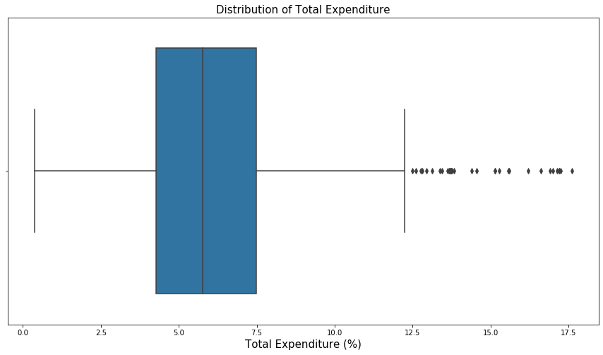

```python
# set the plot size
plt.figure(figsize = (15,8))

# plot a boxplot to check the presence of outliers
sns.boxplot(x = df_life['Total expenditure'])

# add plot and axes labels
# set text size using 'fontsize'
plt.title('Distribution of Total Expenditure', fontsize = 15)
plt.xlabel('Total Expenditure (%)', fontsize = 15)

# display the plot
plt.show()
```

Any percentage above 12.5 is considered as an outlier in the data.

|  | **3b. Remove the outliers present in 'Total expenditure' using the quartiles of the variable** |
| --- | --- |

```python
# check count of 'Total expenditure' before outlier treatment
len(df_life['Total expenditure'])
```

```
2938
```

```python
# calculate the first quartile
Q1 = df_life['Total expenditure'].quantile(0.25)

#calculate the third quartile
Q3 = df_life['Total expenditure'].quantile(0.75)

# The Interquartile Range (IQR) is defined as difference between the third and first quartile
# calculate IQR
IQR = Q3 - Q1

# remove the outliers from the variable
df_life = df_life[~((df_life['Total expenditure'] < (Q1 - 1.5 * IQR)) | (df_life['Total expenditure'] > (Q3 + 1.5 * IQR)))]

# check the count after removing the outliers
len(df_life['Total expenditure'])
```

```
2906
```

The count of observations reduced from 2938 to 2906, which implies the removal of the outliers.

|  | **4. Split the data such that 'X' will contain all the indepentdent variables and 'y' will contain the target variable** |
| --- | --- |

**Hint:** 'Life expectancy' is the target variable depending on the remaining variables.

```python
# dropping the target variable will return the set of independent variables
X = df_life.drop('Life expectancy', axis = 1)
X.head()
```

|  | Country | Year | Status | Adult mortality | Infant deaths | Alcohol | Percentage expenditure | Hepatitis B | Measles | BMI | Under-five deaths | Polio | Total expenditure | Diphtheria | HIV/AIDS | GDP | Population | Thinness 1-19 years | Thinness 5-9 years | Income composition of resources | Schooling |
| --- | --- | --- | --- | --- | --- | --- | --- | --- | --- | --- | --- | --- | --- | --- | --- | --- | --- | --- | --- | --- | --- |
| 0 | Afghanistan | 2015 | Developing | 263.0 | 62 | 0.01 | 71.279624 | 65.0 | 1154 | 19.1 | 83 | 6.0 | 8.16 | 65.0 | 0.1 | 584.259210 | 33736494.0 | 17.2 | 17.3 | 0.479 | 10.1 |
| 1 | Afghanistan | 2014 | Developing | 271.0 | 64 | 0.01 | 73.523582 | 62.0 | 492 | 18.6 | 86 | 58.0 | 8.18 | 62.0 | 0.1 | 612.696514 | 327582.0 | 17.5 | 17.5 | 0.476 | 10.0 |
| 2 | Afghanistan | 2013 | Developing | 268.0 | 66 | 0.01 | 73.219243 | 64.0 | 430 | 18.1 | 89 | 62.0 | 8.13 | 64.0 | 0.1 | 631.744976 | 31731688.0 | 17.7 | 17.7 | 0.470 | 9.9 |
| 3 | Afghanistan | 2012 | Developing | 272.0 | 69 | 0.01 | 78.184215 | 67.0 | 2787 | 17.6 | 93 | 67.0 | 8.52 | 67.0 | 0.1 | 669.959000 | 3696958.0 | 17.9 | 18.0 | 0.463 | 9.8 |
| 4 | Afghanistan | 2011 | Developing | 275.0 | 71 | 0.01 | 7.097109 | 68.0 | 3013 | 17.2 | 97 | 68.0 | 7.87 | 68.0 | 0.1 | 63.537231 | 2978599.0 | 18.2 | 18.2 | 0.454 | 9.5 |

```python
# consider only the target variable
y = df_life['Life expectancy']
y.head()
```

```
0    65.0
1    59.9
2    59.9
3    59.5
4    59.2
Name: Life expectancy, dtype: float64
```

|  | **5. Split the independent variables into two sets with the proportion of 70:30** |
| --- | --- |

```python
# split the dataset into train & test
# import 'train_test_split' from sklearn
from sklearn.model_selection import train_test_split

# set the 'random_state' to generate the same train and test data for every implementation of the code
# X is the set of independent variables
# 'test_size' returns the 30% of the data in test dataset
X_train, X_test = train_test_split(X, test_size = 0.30, random_state = 10)

# print the shape of train and test sets
print("X_train",X_train.shape)
print("X_test",X_test.shape)
```

```
X_train (2034, 21)
X_test (872, 21)
```

|  | **6. How would you treat the missing values in the variable 'GDP'?** |
| --- | --- |

```
null values after treatment: 424
```

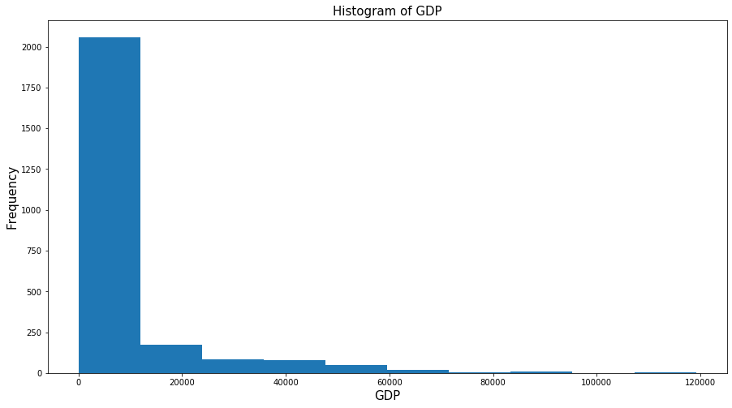

```python
# set the plot size
plt.figure(figsize = (15,8))

# check number of null values in GDP
print("null values after treatment:", df_life['GDP'].isnull().sum())

# plot the histogram
plt.hist(df_life['GDP'])

# assign plot and axes labels
# set text size using 'fontsize'
plt.title('Histogram of GDP', fontsize = 15)
plt.xlabel('GDP', fontsize = 15)
plt.ylabel('Frequency', fontsize = 15)

# display the plot
plt.show()
```

Since the values in the column 'GDP' are imbalanced; we can use the median value to impute the missing observations.

```python
# imputing missing values with median
df_life['GDP'] = df_life['GDP'].fillna(df_life['GDP'].median())

# check the presence of missing values
# any() returns the boolean output
df_life.GDP.isnull().any()
```

```
False
```

The output shows that there is no missing value in 'GDP'.

|  | **7.There are 16 observations for which the status of the corresponding country is unknown, impute this status with an appropriate values** |
| --- | --- |

```python
# check the frequency of each category
df_life.Status.value_counts()
```

```
Developing    2396
Developed      494
Name: Status, dtype: int64
```

Since the class 'Developing' has high frequency, replace the null values with the category 'Developing'.

```python
# as 'Status' is a categorical variable, replace the missing values with most common class
df_life.Status = df_life.Status.fillna(value = 'Developing')

# check the presence of missing values
# any() returns the boolean output
print('No. of missing values:', df_life.Status.isnull().sum())
```

```
No. of missing values: 0
```

```python
# OR

# use the corresponding Percentage expenditure to replace the missing values
# check summary of 'Percentage expenditure'
print('Statistical Summary:', df_life['Percentage expenditure'].describe())

# define a function
# if percentage expenditure is less than its average retrun 'Developing'
# if percentage expenditure is greater than or equal to its average retrun 'Developed'
def missing(var):

    if var < df_life['Percentage expenditure'].quantile(0.5):
        return 'Developing'
    if (var >= df_life['Percentage expenditure'].quantile(0.5)):
        return 'Developed'

# apply the function to impute missing values in 'Status'
df_life['Status'] = df_life['Percentage expenditure'].apply(missing)

# check the presence of missing values
# any() returns the boolean output
print('No. of missing values:', df_life.Status.isnull().sum())
```

```
Statistical Summary: count     2906.000000
mean       745.228181
std       1997.312698
min          0.000000
25%          5.385679
50%         67.655779
75%        447.501609
max      19479.911610
Name: Percentage expenditure, dtype: float64
No. of missing values: 0
```

Both the outputs show that there is no country with missing status.

|  | **8. Define a function to find the extreme values in alcohol consumption** |
| --- | --- |

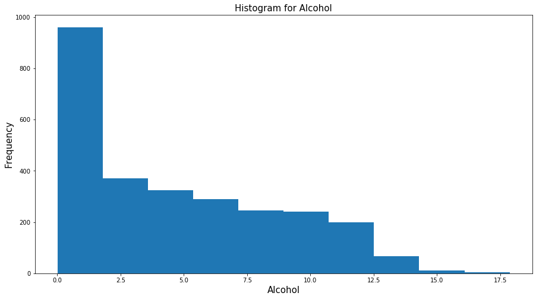

```python
# set the plot size
plt.figure(figsize = (15,8))

# check the presence of extreme points in 'Alcohol'
plt.hist(x = df_life['Alcohol'])

# assign plot and axes labels
# set text size using 'fontsize'
plt.title('Histogram for Alcohol', fontsize = 15)
plt.xlabel('Alcohol', fontsize = 15)
plt.ylabel('Frequency', fontsize = 15)

# display the plot
plt.show()
```

The histogram shows the presence of extreme points in 'Alcohol'. Now, define a function to find the exact values.

```python
# define a funcion
# create an empty list to store the outliers
# set the threshold to 3 as per z-score metric
# calculate mean and standard deviation
# calculate z_score using for loop
# append the observations to the list 'outliers'

outliers=[]
def detect_outlier(data):
    threshold=3
    mean = np.mean(data)
    std =np.std(data)

    for y in data:
        z_score= (y - mean)/std
        if np.abs(z_score) > threshold:
            outliers.append(y)
    return outliers

# call the function to detect outliers
outlier_pt = detect_outlier(df_life.Alcohol)
print("Extreme values for Alcohol:\n" + str(outlier_pt))
```

```
Extreme values for Alcohol:
[17.31, 16.99, 17.87]
```

The three quantities given in the above list are the extreme values in alcohol consumption.

|  | **9. Create a column 'Life_expectancy_level' such that it will contain three levels (High, Medium, Low) based on the life expectancy** |
| --- | --- |

```python
# compute statistical summary
df_life['Life expectancy'].describe()
```

```
count    2898.000000
mean       69.205383
std         9.519585
min        36.300000
25%        63.025000
50%        72.100000
75%        75.600000
max        89.000000
Name: Life expectancy, dtype: float64
```

Use the statistical summary of life expectancy to create the three levels.

```python
# assign a name to the column
age = df_life['Life expectancy']

# define a function to create new levels
# use 'if' statement to pass the conditions
# if life expectancy is less than its 1st quartile retrun 'Low'
# if life expectancy is between its 1st and 3rd quartile retrun 'Medium'
# if life expectancy is greater than its 3rd quartile retrun 'High'
def feature(age):

    if age < df_life['Life expectancy'].quantile(0.25):
        return 'Low'
    if (age >= df_life['Life expectancy'].quantile(0.25)) & (age < df_life['Life expectancy'].quantile(0.75)):
        return 'Medium'
    if (age > df_life['Life expectancy'].quantile(0.75)):
        return 'High'

# apply the function to create a new column
df_life['Life_expectancy_level']= df_life['Life expectancy'].apply(feature)
```

```python
# check the head of the updated dataframe
df_life.head()
```

|  | Country | Year | Status | Life expectancy | Adult mortality | Infant deaths | Alcohol | Percentage expenditure | Hepatitis B | Measles | BMI | Under-five deaths | Polio | Total expenditure | Diphtheria | HIV/AIDS | GDP | Population | Thinness 1-19 years | Thinness 5-9 years | Income composition of resources | Schooling | Life_expectancy_level |
| --- | --- | --- | --- | --- | --- | --- | --- | --- | --- | --- | --- | --- | --- | --- | --- | --- | --- | --- | --- | --- | --- | --- | --- |
| 0 | Afghanistan | 2015 | Developed | 65.0 | 263.0 | 62 | 0.01 | 71.279624 | 65.0 | 1154 | 19.1 | 83 | 6.0 | 8.16 | 65.0 | 0.1 | 584.259210 | 33736494.0 | 17.2 | 17.3 | 0.479 | 10.1 | Medium |
| 1 | Afghanistan | 2014 | Developed | 59.9 | 271.0 | 64 | 0.01 | 73.523582 | 62.0 | 492 | 18.6 | 86 | 58.0 | 8.18 | 62.0 | 0.1 | 612.696514 | 327582.0 | 17.5 | 17.5 | 0.476 | 10.0 | Low |
| 2 | Afghanistan | 2013 | Developed | 59.9 | 268.0 | 66 | 0.01 | 73.219243 | 64.0 | 430 | 18.1 | 89 | 62.0 | 8.13 | 64.0 | 0.1 | 631.744976 | 31731688.0 | 17.7 | 17.7 | 0.470 | 9.9 | Low |
| 3 | Afghanistan | 2012 | Developed | 59.5 | 272.0 | 69 | 0.01 | 78.184215 | 67.0 | 2787 | 17.6 | 93 | 67.0 | 8.52 | 67.0 | 0.1 | 669.959000 | 3696958.0 | 17.9 | 18.0 | 0.463 | 9.8 | Low |
| 4 | Afghanistan | 2011 | Developing | 59.2 | 275.0 | 71 | 0.01 | 7.097109 | 68.0 | 3013 | 17.2 | 97 | 68.0 | 7.87 | 68.0 | 0.1 | 63.537231 | 2978599.0 | 18.2 | 18.2 | 0.454 | 9.5 | Low |

Here, we have created a new columnn by categorizing the 'Life expectancy' into three levels; 'Low', 'Medium', and 'High'.

|  | **10. Check how life expectancy has changed over the years in China** |
| --- | --- |

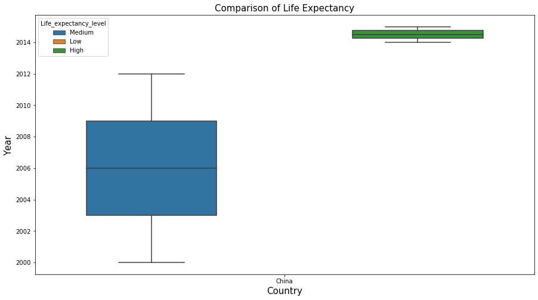

```python
# set the plot size
plt.figure(figsize = (15,8))

# plot a boxplot to compare the life expectancy
# pass life expectancy levels to the parameter, 'hue'
sns.boxplot(x = df_life['Country'][df_life['Country'] == 'China'], y = df_life['Year'], hue = df_life['Life_expectancy_level'])

# assign plot and axes labels
# set text size using 'fontsize'
plt.title('Comparison of Life Expectancy', fontsize = 15)
plt.xlabel('Country', fontsize = 15)
plt.ylabel('Year', fontsize = 15)

# display the plot
plt.show()
```

The above plot shows that, the life expectancy in China has improved significantly over the years.